# Task III

Chathuri Aththanayake

13/12/2020

Thid document contains the work for the Task III

Thsi set of data caotains devise five questions on a five point Likert scale that ask members of your group about their experience with your chosen task

Where; Q1 I consider myself a great jumper Q2 How often do you exercise? Q3 Did you feel tired after jumping for 30 seconds? Q4 Do you have any health condition that makes jumping difficult? Q5 I consider exercising a joyful activity

And five point Likert scale as follows;

strongly agree/everyday :5  
:4  
:3  
:2  
strongly disagree/rarely:1

Let's import data

```r
## Data
Data=read.csv("Task III.csv", header = TRUE)
head(Data)
```

```
##   Q1 Q2 Q3 Q4 Q5
## 1  1  5  2  1  5
## 2  3  2  2  1  3
## 3  1  3  3  2  4
## 4  3  4  1  1  4
## 5  3  2  2  1  5
## 6  3  4  2  1  3
```

```r
summary(Data)
```

```
##        Q1              Q2             Q3             Q4              Q5
##  Min.   :1.000   Min.   :2.00   Min.   :1.00   Min.   :1.000   Min.   :3
##  1st Qu.:1.750   1st Qu.:2.75   1st Qu.:2.00   1st Qu.:1.000   1st Qu.:3
##  Median :3.000   Median :3.00   Median :2.00   Median :1.000   Median :4
##  Mean   :2.375   Mean   :3.25   Mean   :2.25   Mean   :1.625   Mean   :4
##  3rd Qu.:3.000   3rd Qu.:4.00   3rd Qu.:2.25   3rd Qu.:1.250   3rd Qu.:5
##  Max.   :3.000   Max.   :5.00   Max.   :4.00   Max.   :5.000   Max.   :5
```

```r
data=na.omit(Data)# omit the missing values
```

Lets take the covariance matrix of the data to see the interdependencies

```r
#Covariance matrix of the variables
S <- cov(data)
S
```

```
##            Q1         Q2          Q3          Q4         Q5
## Q1  0.8392857 -0.3928571 -0.39285714  0.16071429 -0.1428571
## Q2 -0.3928571  1.0714286 -0.21428571 -0.17857143  0.1428571
## Q3 -0.3928571 -0.2142857  0.78571429 -0.03571429 -0.2857143
## Q4  0.1607143 -0.1785714 -0.03571429  1.98214286  0.5714286
## Q5 -0.1428571  0.1428571 -0.28571429  0.57142857  0.8571429
```

PCA analysis on the data

```r
#Compute the eigenvalues and corresponding eigenvectors of S.

s.eigen <- eigen(S)
s.eigen
```

```
## eigen() decomposition
## $values
## [1] 2.2625525 1.4369832 1.1609501 0.5596299 0.1155985
##
## $vectors
##            [,1]         [,2]       [,3]       [,4]       [,5]
## [1,] -0.1276759  0.522203242  0.5374246 -0.2439676 -0.6022103
## [2,]  0.1143424 -0.761064496  0.1889498 -0.5307207 -0.3005664
## [3,]  0.1102993  0.098913824 -0.7763289 -0.0485892 -0.6107394
## [4,] -0.9076687 -0.007021294 -0.2130390 -0.3363727  0.1324995
## [5,] -0.3668737 -0.371821682  0.1655312  0.7370942 -0.3955299
```

```r
#proportion of the total variance explained by the components.

for (s in s.eigen$values) {
  print(s / sum(s.eigen$values))
}
```

```
## [1] 0.4087192
## [1] 0.2595841
## [1] 0.20972
## [1] 0.1010944
## [1] 0.02088231
```

Lets plot the scree plot to identify the PC

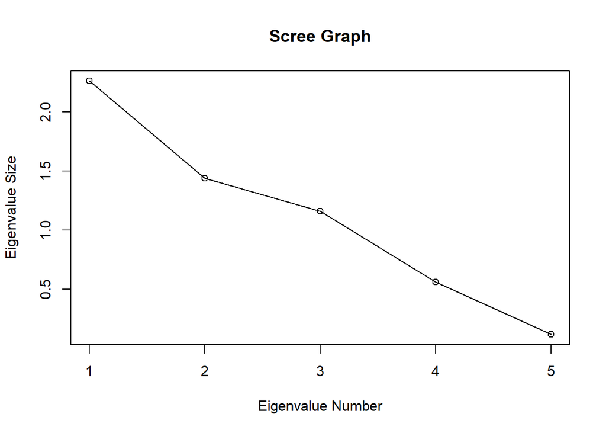

```r
#A scree graph of the eigenvalues

plot(s.eigen$values, xlab = 'Eigenvalue Number', ylab = 'Eigenvalue Size', main = 'Scree Graph')
lines(s.eigen$values)
```

To write the PC

```r
s.eigen$vectors
```

```
##            [,1]         [,2]       [,3]       [,4]       [,5]
## [1,] -0.1276759  0.522203242  0.5374246 -0.2439676 -0.6022103
## [2,]  0.1143424 -0.761064496  0.1889498 -0.5307207 -0.3005664
## [3,]  0.1102993  0.098913824 -0.7763289 -0.0485892 -0.6107394
## [4,] -0.9076687 -0.007021294 -0.2130390 -0.3363727  0.1324995
## [5,] -0.3668737 -0.371821682  0.1655312  0.7370942 -0.3955299
```

Visualize the results

```r
#Visualize
library(ggfortify)
```

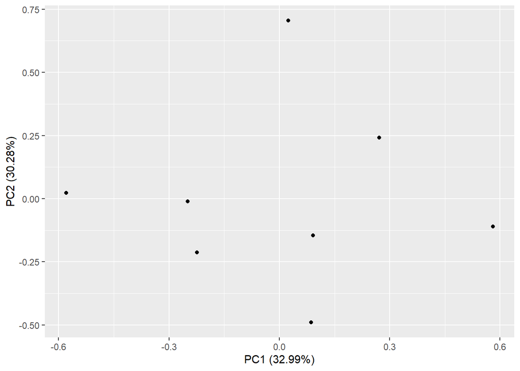

```r
library(ggplot2)
pca_res <- prcomp(data, scale. = TRUE)
autoplot(pca_res)
```